# Project Kelompok 11 - Fahmi

## Cek rataan data train stasioner dengan Uji ADF

$H_0$ : Data train tidak stasioner dalam rataan

$H_1$ : Data train stasioner dalam rataan

```r
tseries::adf.test(DataTrain)
```

```
##
##  Augmented Dickey-Fuller Test
##
## data:  DataTrain
## Dickey-Fuller = -0.83342, Lag order = 8, p-value = 0.9586
## alternative hypothesis: stationary
```

Berdasarkan uji ADF tersebut, didapat *p-value* yang lebih besar dari 0.05 sehingga tak tolak $H_0$. Artinya, data train **tidak stasioner dalam rataan**.

## Cek ragam data train stasioner dengan Plot Boxcox

```r
index <- seq(1, 576)

# Box-Cox
bc <- boxcox(DataTrain ~ index, lambda = seq(-8, 4, by = 0.01)
)
```

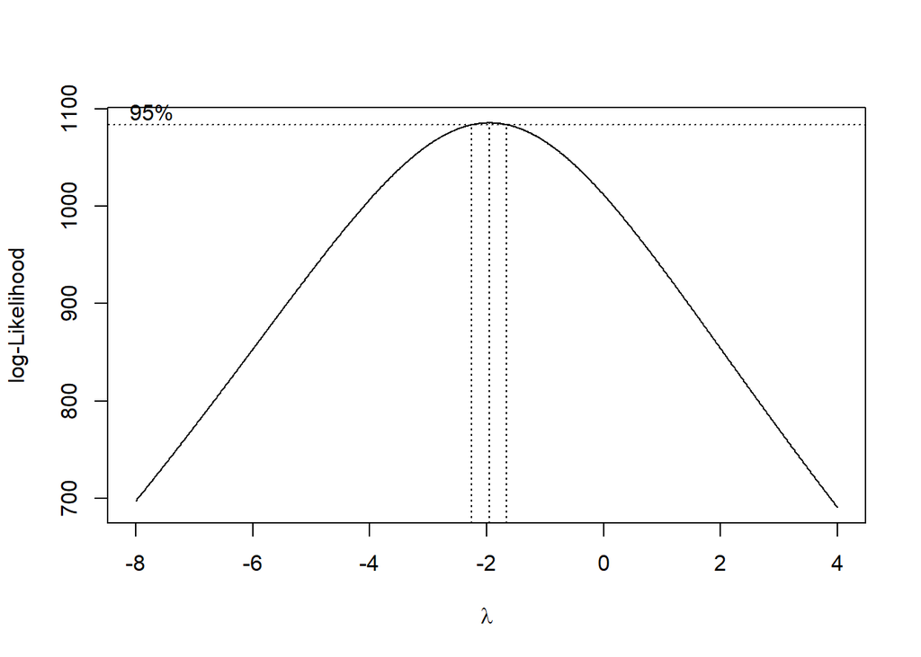

```r
lambda <- bc$x[which.max(bc$y)]
lambda
```

```
## [1] -1.95
```

```r
# Selang kepercayaan 95% untuk lambda
ci_lambda <- bc$x[bc$y > max(bc$y) - 0.5 * qchisq(0.95, 1)]

# Batas bawah dan batas atas
ci_lower <- min(ci_lambda)
ci_upper <- max(ci_lambda)

c(Batas_Bawah = ci_lower, Batas_Atas = ci_upper)
```

```
## Batas_Bawah  Batas_Atas
##       -2.25       -1.66
```

Gambar di atas menunjukkan nilai λ optimum (rounded value) sebesar **-1.95** dan selang kepercayaan 95% nilai memiliki batas bawah **-2.25** dan batas atas **-1.66**. Selang tersebut tidak memuat nilai satu sehingga terdapat cukup bukti untuk mengatakan bahwa data train saya **tidak stasioner dalam ragam** pada taraf nyata 5%.

## Kesimpulan dari data

Data train saya **tidak stasioner dalam rataan dan tidak stasioner dalam ragam** pada taraf nyata 5%.

## Penanganan pada data train

### Differencing pertama

```r
# Differencing pertama pada DataTrain
DataTrain_diff1 <- diff(DataTrain, differences = 1)
```

#### Plot hasil differencing pertama

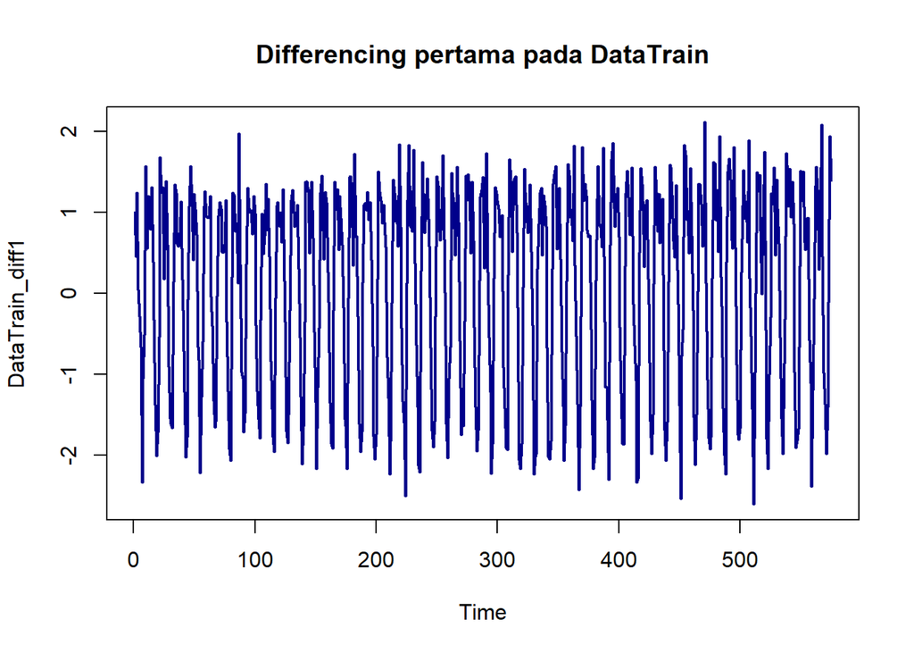

```r
ts.plot(DataTrain_diff1,
        main = "Differencing pertama pada DataTrain",
        col = "darkblue", lwd = 2)
```

Plot hasil differencing (Differencing pertama pada DataTrain) menunjukkan data train sekarang berfluktuasi di sekitar nilai nol.

Tren naik sudah hilang karena saya telah melakukan differencing orde 1.

#### Plot ACF hasil differencing pertama

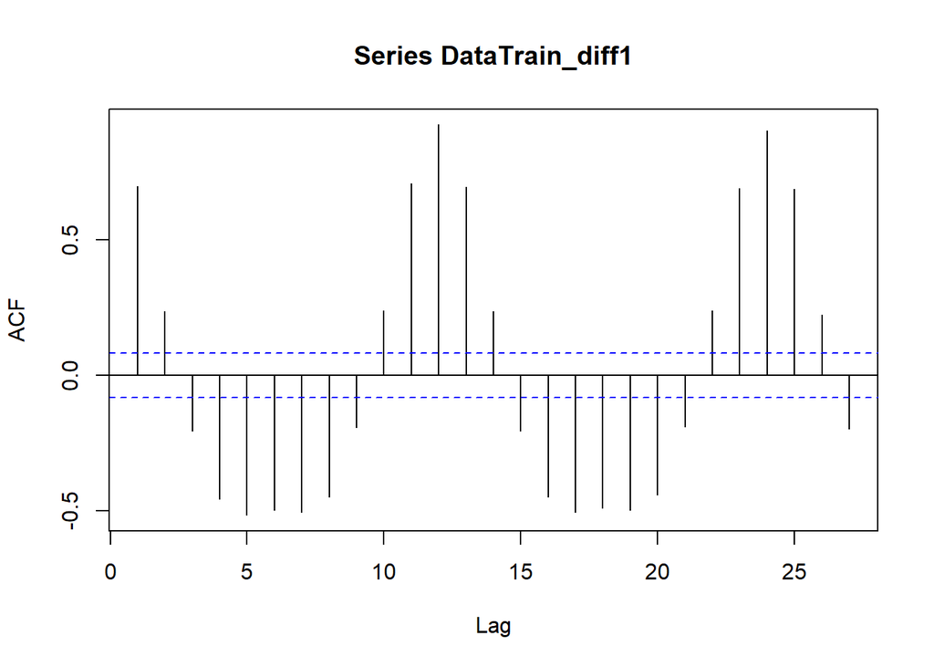

```r
acf(DataTrain_diff1)
```

#### Uji ADF hasil differencing pertama

$H_0$ : Data train hasil differencing pertama tidak stasioner dalam rataan

$H_1$ : Data train hasil differencing pertama stasioner dalam rataan

```r
tseries::adf.test(DataTrain_diff1)
```

```
##
##  Augmented Dickey-Fuller Test
##
## data:  DataTrain_diff1
## Dickey-Fuller = -31.044, Lag order = 8, p-value = 0.01
## alternative hypothesis: stationary
```

Berdasarkan uji ADF tersebut, didapat *p-value* yang lebih kecil dari 0.01 yang lebih kecil dari taraf nyata 5% sehingga tolak $H_0$ dan menandakan bahwa data train hasil differencing pertama **stasioner dalam rataan**. Hal ini sesuai dengan hasil eksplorasi menggunakan plot time series dan plot ACF terhadap data train hasil differencing pertama.

#### Cek ragam data train hasil differencing pertama stasioner dengan Plot Boxcox

```r
# Box-Cox
index1 <- seq(1, 575)

# 1. Hitung nilai minimum
min_val <- min(DataTrain_diff1)

# 2. Tentukan konstanta pergeseran (misalnya min_val + 1)
c <- abs(min_val) + 1

# 3. Buat variabel respons yang sudah digeser
DataTrain_diff1_shifted <- DataTrain_diff1 + c

# 4. Terapkan boxcox pada data yang sudah digeser
bc1 <- boxcox(DataTrain_diff1_shifted ~ index1, lambda = seq(-2, 6, by = 0.01))
```

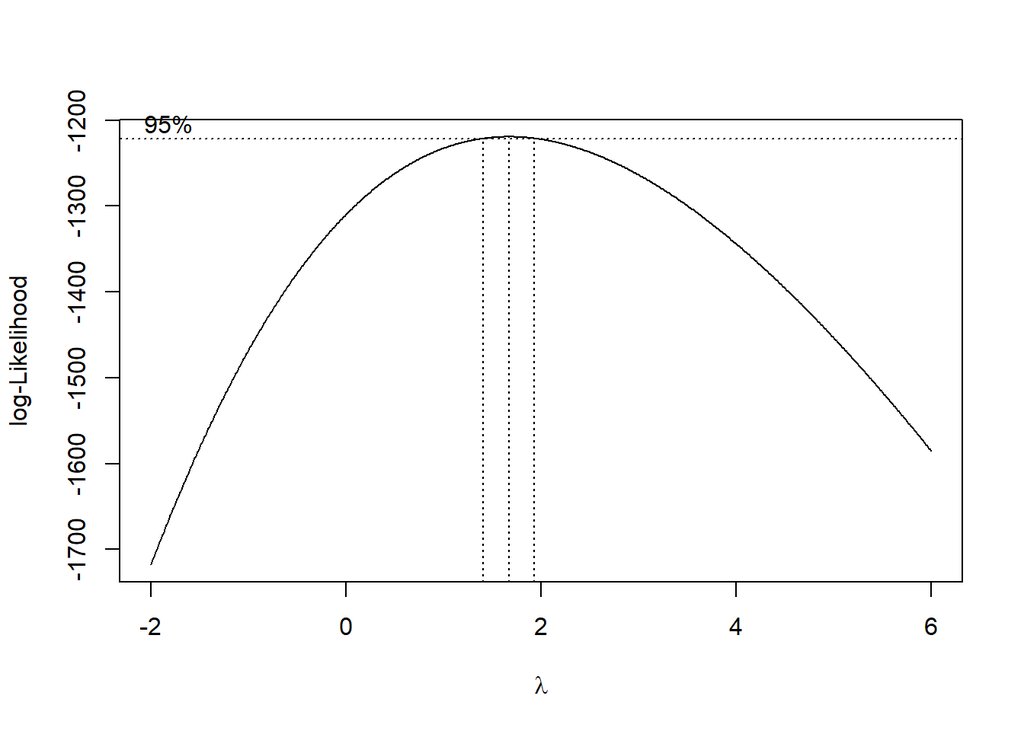

# Permodelan SARIMA

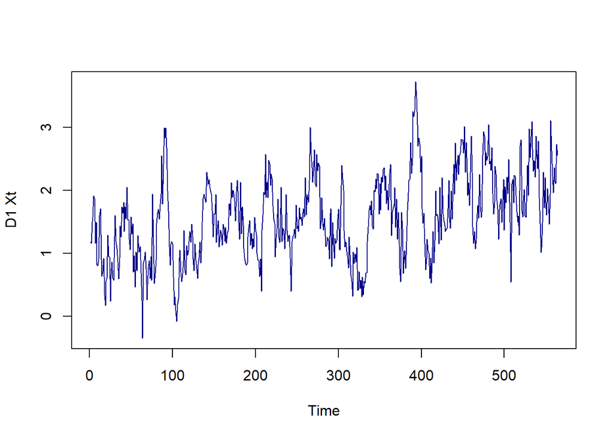

```r
D1 <- diff(DataTrain,12)
ts.plot(D1, type="l", ylab="D1 Xt", col="darkblue")
```

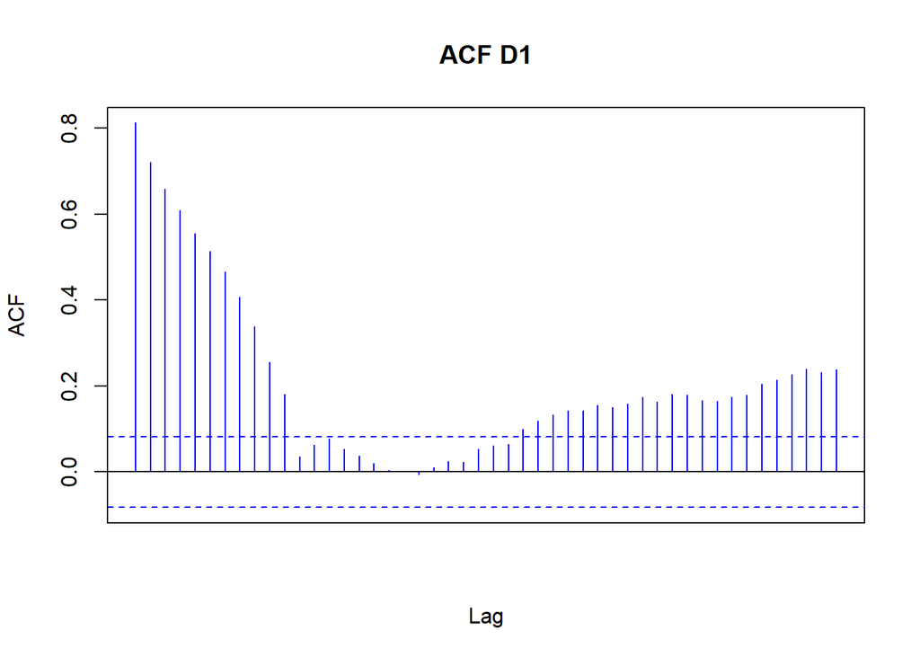

```r
acf2<-acf(D1,lag.max=48,xaxt="n", main="ACF D1", col="blue")
```

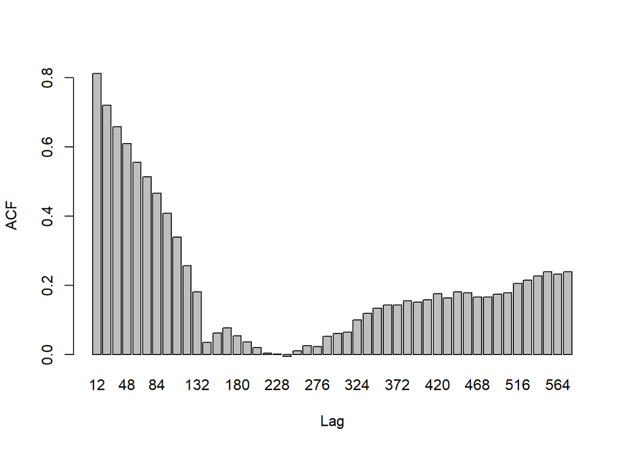

```r
acf2$lag <- acf2$lag * 12
acf2.1 <- as.data.frame(cbind(acf2$acf,acf2$lag))
acf2.2 <- acf2.1[which(acf2.1$V2%%12==0),]
barplot(height = acf2.2$V1, names.arg=acf2.2$V2, ylab="ACF", xlab="Lag")
```

Untuk menghilangkan kecenderungan musiman dilakukan pembedaan musiman terhadap deret hasil pembedaan pertama.

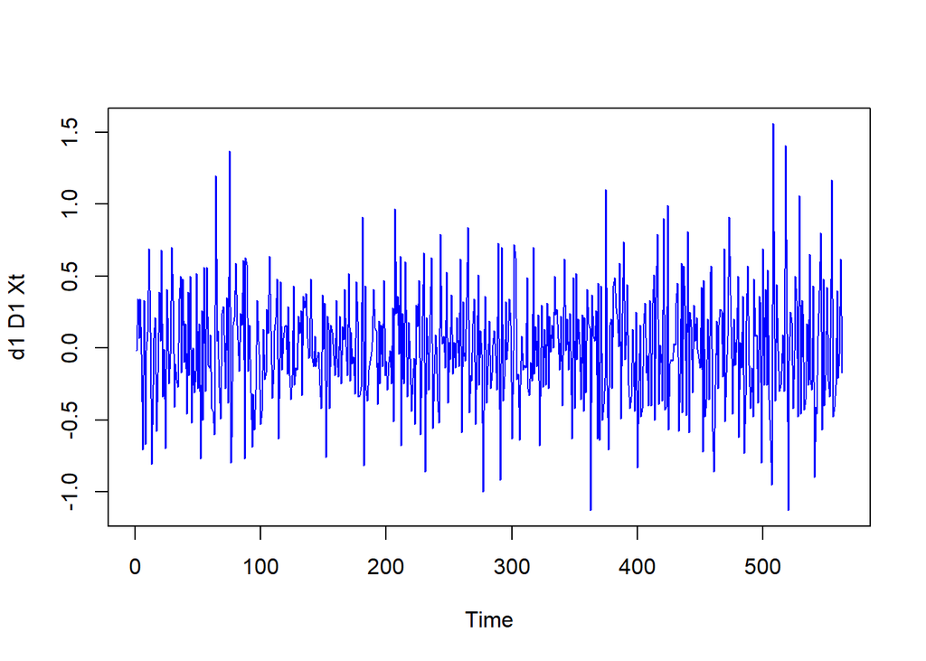

```r
d1D1 <- diff(D1)
ts.plot(d1D1, type="l", ylab="d1 D1 Xt", col="blue")
```

Setelah pembedaan pertama dan pembedaan musiman tampak bahwa deret sudah tidak memiliki kecenderungan apapun. Selanjutnya penentuan ordo p, q dan P, Q dapat dilakukan menggunakan plot ACF dan PACF contoh dari deret hasil pembedaan pertama dan pembedaan musiman tersebut.

# Identifikasi Model

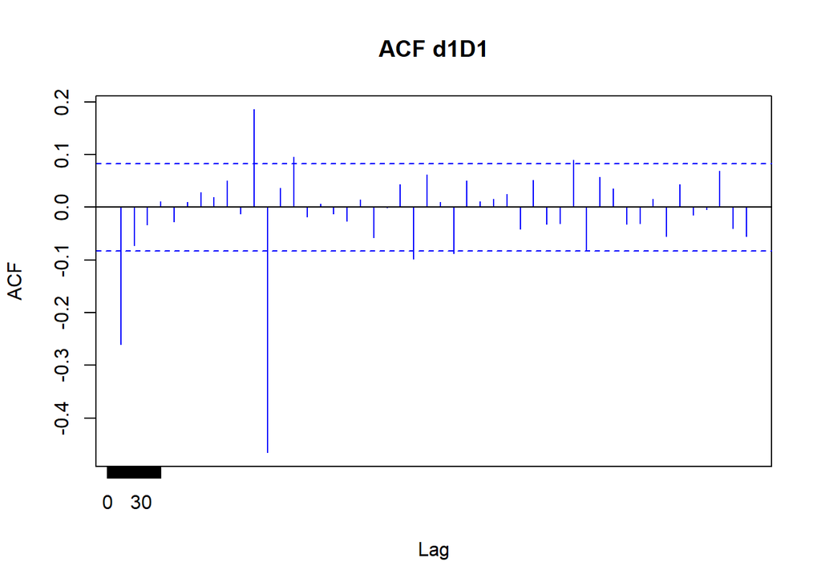

```r
acf3 <- acf(d1D1,lag.max=48,xaxt="n", main="ACF d1D1", col="blue")
axis(1, at=0:48/12, labels=0:48)
```

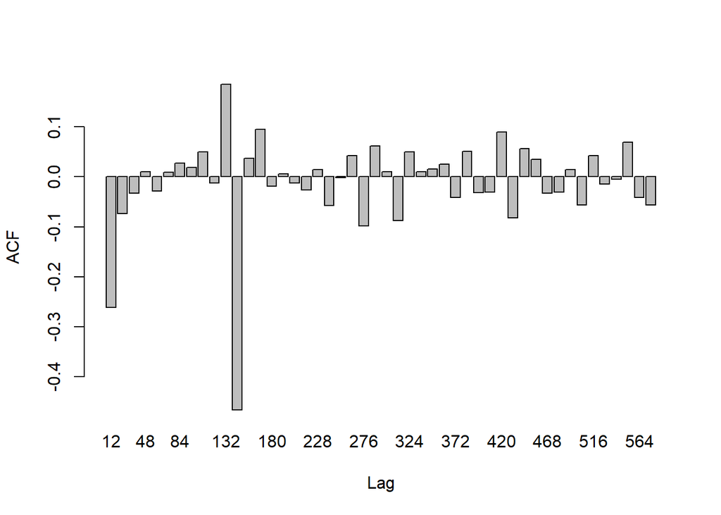

```r
acf3$lag <- acf3$lag * 12
acf3.1 <- as.data.frame(cbind(acf3$acf,acf3$lag))
acf3.2 <- acf3.1[which(acf3.1$V2%%12==0),]
barplot(height = acf3.2$V1, names.arg=acf3.2$V2, ylab="ACF",
xlab="Lag")
```

Berdasarkan plot ACF contoh lag 1 signifikan sehingga dipilih ordo q=1 , dan lag 12 adalah satu-satunya lag musiman yang signifikan sehingga order Q=1.

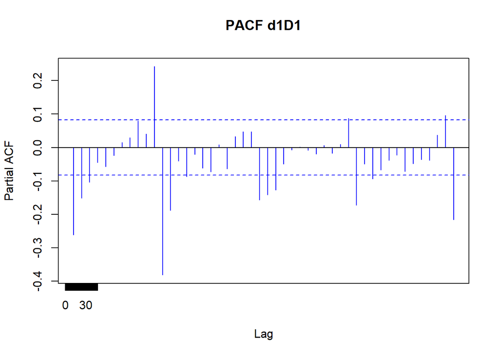

```r
pacf3 <- pacf(d1D1,lag.max=48,xaxt="n", main="PACF d1D1", col="blue")
axis(1, at=0:48/12, labels=0:48)
```

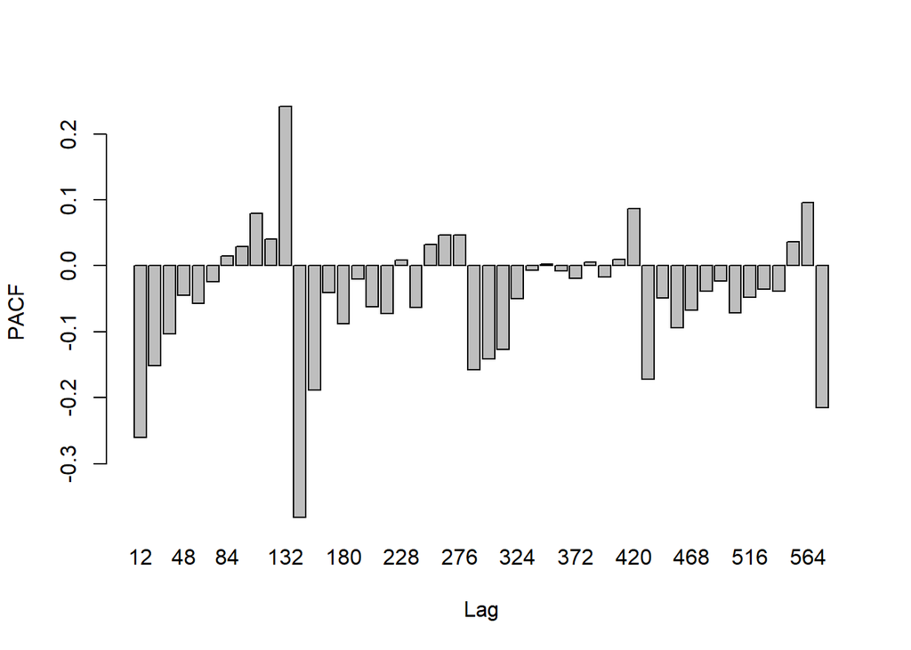

```r
pacf3$lag <- pacf3$lag * 12
pacf3.1 <- as.data.frame(cbind(pacf3$acf,pacf3$lag))
pacf3.2 <- pacf3.1[which(pacf3.1$V2%%12==0),]
barplot(height = pacf3.2$V1, names.arg=pacf3.2$V2, ylab="PACF", xlab="Lag")
```

Model musiman yang dipilih untuk deret konsentrasi karbon dioksida adalah ARIMA(0,1,1) X (0,1,1)12, ARIMA(1,1,0) X (0,1,1)12, dan ARIMA(1,1,1) X (0,1,1)12